# Vignette for package `bayesmsm`

Xiao Yan, Kuan Liu

**1. Introduction**

- The `bayesmsm` package enables easy implementation of the Bayesian marginal structural models (BMSMs) for longitudinal data. The methodology of BMSMs can be divided into 2 estimation steps:
  - Step 1. Bayesian treatment effect weight estimation
  - Step 2. Bayesian non-parametric bootstrap to maximize the utility function with respect to the causal effect
- For Step 1, we estimate treatment weights $w_{ij}$ using posterior samples of the $\alpha$ and $\beta$ via fitting a series of logistic regressions in a Bayesian framework. The package incorporates both Inverse Probability of Treatment Weighting (IPTW) and Inverse Probability of Censoring Weighting (IPCW) to handle longitudinal data without and with right-censoring. For Step 2, $P_n(v_{ij})$ is estimated via non-parametric Bayesian bootstrap with $Dir(1,...,1)$ sampling weights.
- The main functions in this package include:
  - `bayesweight`: Calculates Bayesian weights for subject-specific treatment effects.
  - `bayesmsm`: Estimates marginal structural models using the calculated Bayesian weights.
  - `plot_ATE`: Plots the estimated Average Treatment Effect (ATE).
  - `plot_APO`: Plots the estimated Average Potential Outcome (APO).
  - `plot_est_box`: Plots the distribution of estimated treatment effects.
- Installation
  - To install the bayesmsm package, you can use the `devtools` package to install it directly from GitHub:

```r
devtools::install_github("Kuan-Liu-Lab/bayesmsm")
library(bayesmsm)
```

**2. Simulated observational data with a time-dependent treatment**

- The simulated dataset (continuous outcome)
  - 1000 patients and 3 visits (2 of which patients were assigned a treatment)
  - y, an end-of-study continuous outcome
  - z, a binary treatment
  - w1 and w2 are two baseline covariates (one continuous and one binary, mimicking age and sex)
  - L1 and L2 are two time-dependent covariates (also one continuous and one binary)
  - no missing data
- The simulated DAG

```r
library(DiagrammeR)
grViz("
    digraph causal {
    # Nodes
    node [shape=plaintext]
    W [label = 'w1, w2']
    L1 [label = 'L11, L21']
    Z1 [label = 'Z1']
    L2 [label = 'L12, L22']
    Z2 [label = 'Z2']
    Y [label = 'Y']

    # Edges
    edge [color=black, arrowhead=vee]
    rankdir = LR
    W->L1
    W->Z1
    W->L2
    W->Z2
    W->Y
    L1->Z1
    L1->L2
    L1->Z2
    L1->Y
    Z1->L2
    Z1->Z2
    Z1->Y
    L2->Z2
    L2->Y
    Z2->Y

    # Graph
    graph [overlap=true, fontsize=14]
    }")
```

[interactive chart not shown]

```r
library(DT)
options(scipen = 999)

testdata <- read.csv(system.file("extdata", "continuous_outcome_data.csv", package = "bayesmsm"))

# look at the data;
datatable(testdata,
          rownames = FALSE,
          options = list(dom = 't')) %>%
  formatRound(columns=c('w2', 'L2_1', 'L2_2', 'y'), digits=2)
```

| w1 | w2 | L1_1 | L2_1 | a_1 | L1_2 | L2_2 | a_2 | y |
| --- | --- | --- | --- | --- | --- | --- | --- | --- |
| 0 | 9.592428616059934 | 0 | -0.4156794360289815 | 0 | 1 | -0.123205373308362 | 0 | 0.9773711545806334 |
| 1 | 8.025205635605143 | 1 | 0.3271899354836821 | 0 | 0 | 1.047555180506998 | 0 | 0.5193337934770335 |
| 0 | 16.10714022429962 | 0 | -0.3805177693787017 | 0 | 0 | 0.451557820766288 | 1 | -0.8161817197462765 |
| 1 | 15.00424521042529 | 0 | 1.379270099147326 | 0 | 1 | 0.2351547861193508 | 0 | 3.606631509010199 |
| 1 | 5.963333850685196 | 0 | 0.2437692136130012 | 0 | 0 | -1.732707030669677 | 0 | -0.1648255548418869 |
| 0 | 11.61941019660285 | 0 | -0.4990742141304494 | 0 | 1 | 1.822445952206404 | 0 | 3.545485590765318 |
| 1 | 8.416208708974004 | 1 | -1.712730876995588 | 0 | 0 | -1.407178859994681 | 1 | 1.705565029577714 |
| 1 | 3.716995717832145 | 0 | -0.5965111487177179 | 1 | 0 | -0.3936989313545899 | 1 | -2.095068126972874 |
| 1 | 12.60048052475257 | 1 | 2.182023657380342 | 1 | 0 | 0.9050599443297667 | 0 | 1.057052370264873 |
| 0 | 11.68315316296565 | 1 | -0.4439308895014084 | 0 | 0 | 0.8054504839383311 | 0 | 3.168142940840214 |

[output cut: 990 more lines]

- Frequency Counts by Treatment Combinations

```r
# frequency counts by treatment combinations;
table(testdata$a_1, testdata$a_2)
```

```
#>
#>       0   1
#>   0 520 201
#>   1 111 168
```

- Suppose the causal parameter of interest is the average treatment effect between always treated and never treated,

$$ATE = E(Y \mid Z_1 = 1, Z_2 = 1) - E(Y \mid Z_1 = 0, Z_2 = 0)$$

**3. Bayesian treatment effect weight estimation using `bayesweight`**

- The following code calls the function `bayesweight` to run JAGS and calculate the weights.
  - Non-parallel computing requires that `n.chains = 1`. Parallel MCMC requires at least 2 chains because computing is running on 1 core per chain, and we recommend using at most 2 chains less than the number of available cores on your computer.
  - Running this function automatically saves a JAGS model file in the working directory, which the user can check to review the model specifications.
- Parameters Description:
  - `trtmodel.list`: A list of formulas corresponding to each time point with the time-specific treatment variable on the left hand side and pre-treatment covariates to be balanced on the right hand side. Interactions and functions of covariates are allowed.
  - `data`: The dataset containing all the variables specified in trtmodel.list.
  - `n.iter`: Total number of iterations for each chain (including burn-in).
  - `n.burnin`: Number of iterations to discard at the beginning of the simulation (burn-in).
  - `n.thin`: Thinning rate for the MCMC sampler.
  - `n.chains`: Number of MCMC chains to run. For non-parallel execution, this should be set to 1. For parallel execution, it requires at least 2 chains.
  - `seed`: Seed to ensure reproducibility.
  - `parallel`: Logical flag indicating whether to run the MCMC chains in parallel. Default is TRUE.

```r
weights <- bayesweight(trtmodel.list = list(a_1 ~ w1 + w2 + L1_1 + L2_1,
                                             a_2 ~ w1 + w2 + L1_1 + L2_1 + L1_2 + L2_2 + a_1),
                        data = testdata,
                        n.iter = 250,
                        n.burnin = 150,
                        n.thin = 5,
                        n.chains = 2,
                        seed = 890123,
                        parallel = TRUE)
str(weights)
```

```
#>  num [1:1000] 1.25 1.096 1.063 0.863 0.802 ...
```

- It returns a list containing:
  - `weights`: The calculated weights for subject-specific treatment effects.

**4. Bayesian non-parametric bootstrap to maximize the utility function with respect to the causal effect using `bayesmsm`**

The function `bayesmsm` estimates causal effect of time-varying treatments. It uses subject-specific treatment assignmennt weights *weights* calculated using `bayesweight`, and performs Bayesian non-parametric bootstrap to estimate the causal parameters.

- Parameters Description:
  - `ymodel`: A formula representing the outcome model, which can include interactions and functions of covariates.
  - `nvisit`: Specifies the number of visits or time points considered in the model.
  - `reference`: The baseline or reference intervention across all visits, typically represented by a vector of zeros indicating no treatment (default is a vector of all zeros).
  - `comparator`: The comparison intervention across all visits, typically represented by a vector of ones indicating full treatment (default is a vector of all ones).
  - `family`: Specifies the outcome distribution family; use “gaussian” for continuous outcomes or “binomial” for binary outcomes (default is “gaussian”).
  - `data`: The dataset containing all variables required for the model.
  - `wmean`: A vector of treatment assignment weights. Default is a vector of ones, implying equal weighting.
  - `nboot`: The number of bootstrap iterations to perform for estimating the uncertainty around the causal estimates.
  - `optim_method`: The optimization method used to find the best parameters in the model (default is ‘BFGS’).
  - `seed`: A seed value to ensure reproducibility of results.
  - `parallel`: A logical flag indicating whether to perform computations in parallel (default is TRUE).
  - `ncore`: The number of cores to use for parallel computation (default is 4).

```r
model <- bayesmsm(ymodel = y ~ a_1+a_2,
                           nvisit = 2,
                           reference = c(rep(0,2)),
                           comparator = c(rep(1,2)),
                           family = "gaussian",
                           data = testdata,
                           wmean = weights,
                           nboot = 1000,
                           optim_method = "BFGS",
                           parallel = TRUE,
                           seed = 890123,
                           ncore = 2)
str(model)
```

```
#> List of 6
#>  $ RD_mean    : num -3.17
#>  $ RD_sd      : num 0.0946
#>  $ RD_quantile: Named num [1:2] -3.34 -2.99
#>   ..- attr(*, "names")= chr [1:2] "2.5%" "97.5%"
#>  $ bootdata   :'data.frame': 1000 obs. of  3 variables:
#>   ..$ effect_reference : num [1:1000] 2.37 2.29 2.27 2.35 2.32 ...
#>   ..$ effect_comparator: num [1:1000] -0.94 -0.821 -0.752 -0.795 -0.759 ...
#>   ..$ RD               : num [1:1000] -3.31 -3.11 -3.02 -3.14 -3.08 ...
#>  $ reference  : num [1:2] 0 0
#>  $ comparator : num [1:2] 1 1
```

**5. Visualization functions: `plot_ATE`, `plot_APO`, `plot_est_box`**

The `bayesmsm` package also provides several other functions for visualizing the above results: `plot_ATE`, `plot_APO`, and `plot_est_box`. These functions help the user better interpret the estimated causal effects.

- Plotting the Average Treatment Effect (ATE)
  - The `plot_ATE` function generates a plot of the estimated ATE with its 95% credible interval.

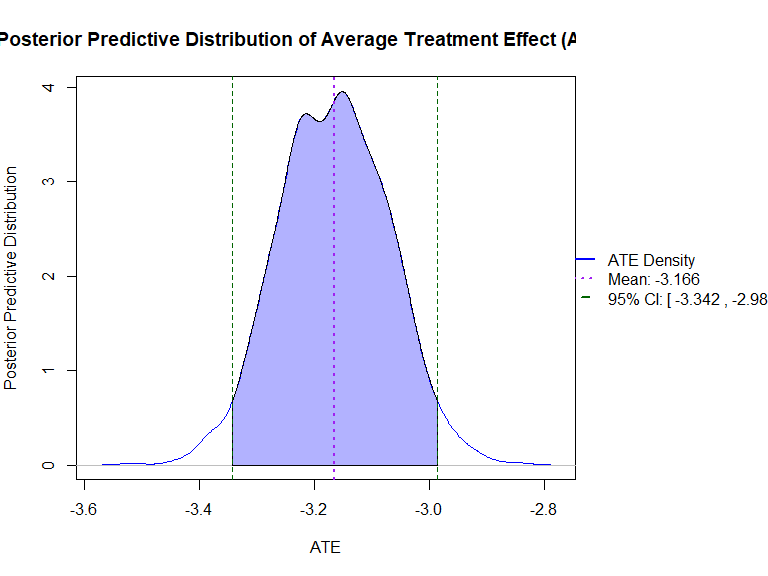

```r
plot_ATE(model)
```

- Plotting the Average Potential Outcome (APO)
  - Similarly, the `plot_APO` function plots the estimated APO for both the reference and comparator level effects.

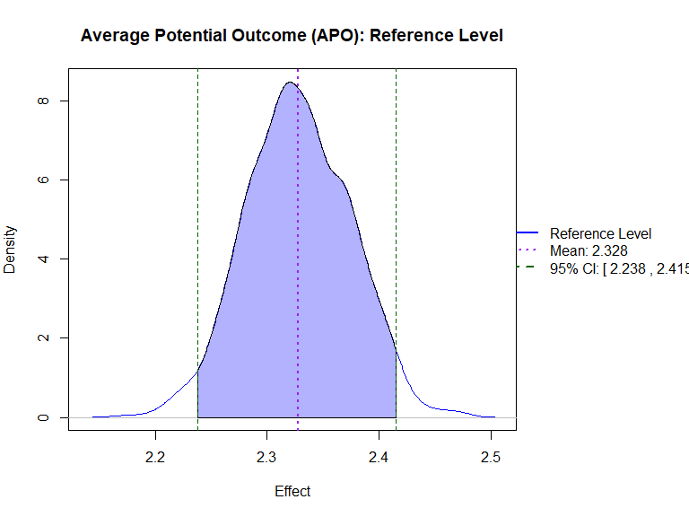

```r
plot_APO(model, "effect_reference")
```

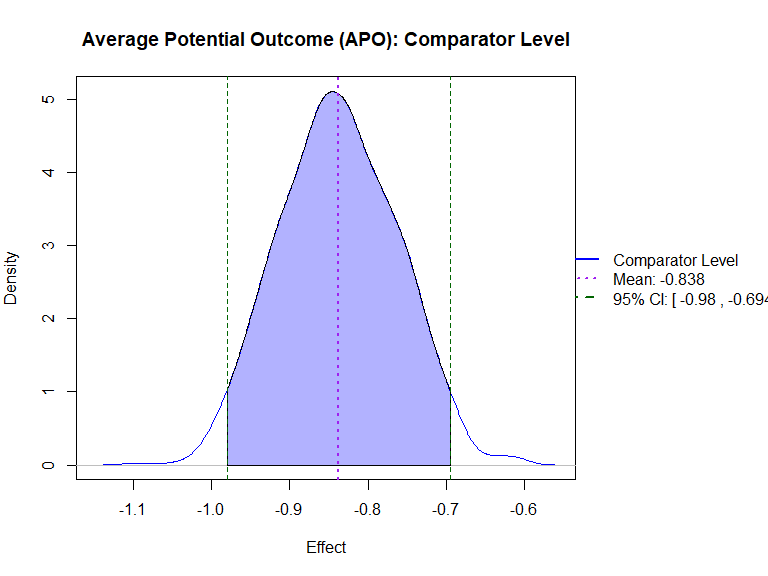

```r
plot_APO(model, "effect_comparator")
```

- Plotting the Distribution of Estimated Treatment Effects
  - The `plot_est_box` function generates an error bar plot of the estimated treatment effects (APO and ATE) from the bootstrap samples.

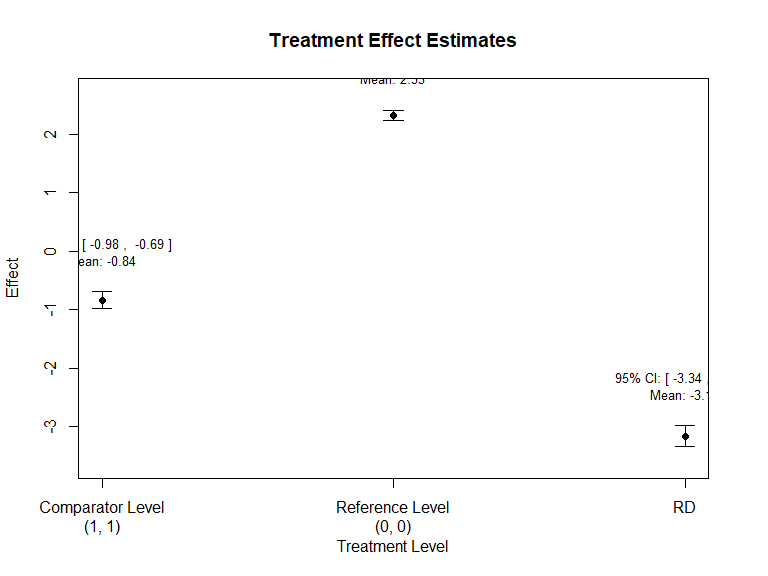

```r
plot_est_box(model)
```

**Reference**

- Liu, K. (2021). Bayesian causal inference with longitudinal data. Tspace.library.utoronto.ca. https://tspace.library.utoronto.ca/handle/1807/109330
- Saarela, O., Stephens, D. A., Moodie, E. E. M., & Klein, M. B. (2015). On Bayesian estimation of marginal structural models. Biometrics, 71(2), 279–288. https://doi.org/10.1111/biom.12269
- Robins, J. M., Hernán, M. A., & Brumback, B. (2000). Marginal structural models and causal inference in epidemiology. Epidemiology, 11(5), 550–560. https://doi.org/10.1097/00001648-200009000-00011
- Liu, K., Saarela, O., Feldman, B. M., & Pullenayegum, E. (2020). Estimation of causal effects with repeatedly measured outcomes in a Bayesian framework. Statistical Methods in Medical Research, 29(9), 2507–2519. https://doi.org/10.1177/0962280219900362